# La poule qui chante, étude de marché

Techniques de clustering pour effectuer une segmentation client

Emmanuel Messori

27/07/2021

# Présentation des données

# Source

Nous utiliserons le fichier comprenant toutes les données sur les bilans alimentaires disponibles sur le site [FAO](http://www.fao.org/faostat/fr/#data/FBS), pour repérer les données qui concernent la viande de volaille (production, importation et exportation, disponibilité en kcal/jour par personne). Ensuite nous allons joindre d’autres indicateurs toujours repérés sur le même site qui pourront fournir au final un cadre assez complet du profil économique des pays.

# Dataframe final

Le dataframe utilisée pour l’analyse contient 173 et les 19 variables suivantes, comprenant les données 2018:

1. `produits_vegetaux_dispo_alim` : total en kcal/personne/jour.
2. `total_dispo_alim`: total de la disponibilité alimentaire en kcal/personne/jour.
3. `viande_dispo_alim` : total de la disponibilité alimentaire de viande en kcal/personne/jour.
4. `viande_export`: total des exportation de viande en milliers de tonnes.
5. `viande_import` : total des importation de viande en milliers de tonnes.
6. `viande_prod` : total de la production de viande en milliers de tonnes.
7. `viande_volaille_dispo_alim`: total de la disponibilité alimentaire en kcal/personne/jour.
8. `viande_volaille_export`: total exports de viande de volaille
9. `viande_volaille_import`: total des importations de viande de volaille
10. `viande_volaille_prod`: total de la productions de viande de volaille
11. `population` : en milliers de personnes.
12. `population_croissance` : taux de croissance 2017-2018
13. `prix_prod_index`: index du prix à la production(viande de volaille)
14. `pib_habitant`: pib habitant en $ 15 `taux_malnutrition`: prévalence de la sous alimentation
15. `prop_import_export`: rapport entre importations et exportations totales
16. `stab_politique`: indice de stabilité politique
17. `inflation_2020`: indice d’inflation des prix des produits alimentaires (données 2020)
18. `prix_conso_2020`: indice des prix à la consommation (données 2020)

```r
head(countries.data)
```

|  | produits_vegetaux_dispo_alim | total_dispo_alim | viande_dispo_alim | viande_export | viande_import | viande_prod | viande_volaille_dispo_alim | viande_volaille_export | viande_volaille_import | viande_volaille_prod | population | population_croissance | prix_prod_index | pib_habitant | taux_malnutrition | prop_import_export | stab_politique | inflation_2020 | prix_conso_2020 |
| --- | --- | --- | --- | --- | --- | --- | --- | --- | --- | --- | --- | --- | --- | --- | --- | --- | --- | --- | --- |
| Afghanistan | 1849 | 2040 | 55 | 0 | 30 | 331 | 5 | 0 | 25 | 29 | 37172 | 0.0241348909 | 85.02 | 2033.8 | 23.4 | 305 | -2.75 | 8.06 | 125.32 |
| Afrique du Sud | 2420 | 2899 | 331 | 121 | 576 | 3241 | 155 | 48 | 515 | 1762 | 57793 | 0.0137344326 | 128.90 | 12627.9 | 5.5 | 6 | -0.22 | 4.39 | 132.99 |
| Albanie | 2357 | 3360 | 215 | NA | 17 | 96 | 50 | NA | 12 | 16 | 2883 | -0.0003467406 | 83.46 | 13323.8 | 4.0 | 22 | 0.38 | 3.61 | 117.50 |
| Algérie | 2932 | 3322 | 93 | 1 | 52 | 806 | 24 | NA | 0 | 295 | 42228 | 0.0202710865 | 111.28 | 11642.2 | 0.0 | 22 | -0.83 | 0.21 | 111.86 |
| Allemagne | 2468 | 3554 | 321 | 3563 | 2700 | 8189 | 67 | 640 | 871 | 1571 | 83124 | 0.0056376878 | 79.81 | 53463.4 | 0.0 | 5 | 0.60 | 2.26 | 109.65 |
| Angola | 2177 | 2385 | 128 | 0 | 467 | 262 | 39 | 0 | 335 | 27 | 30810 | 0.0333031492 | NA | 6933.5 | 15.5 | 7 | -0.32 | 26.63 | 292.44 |

# Données manquantes

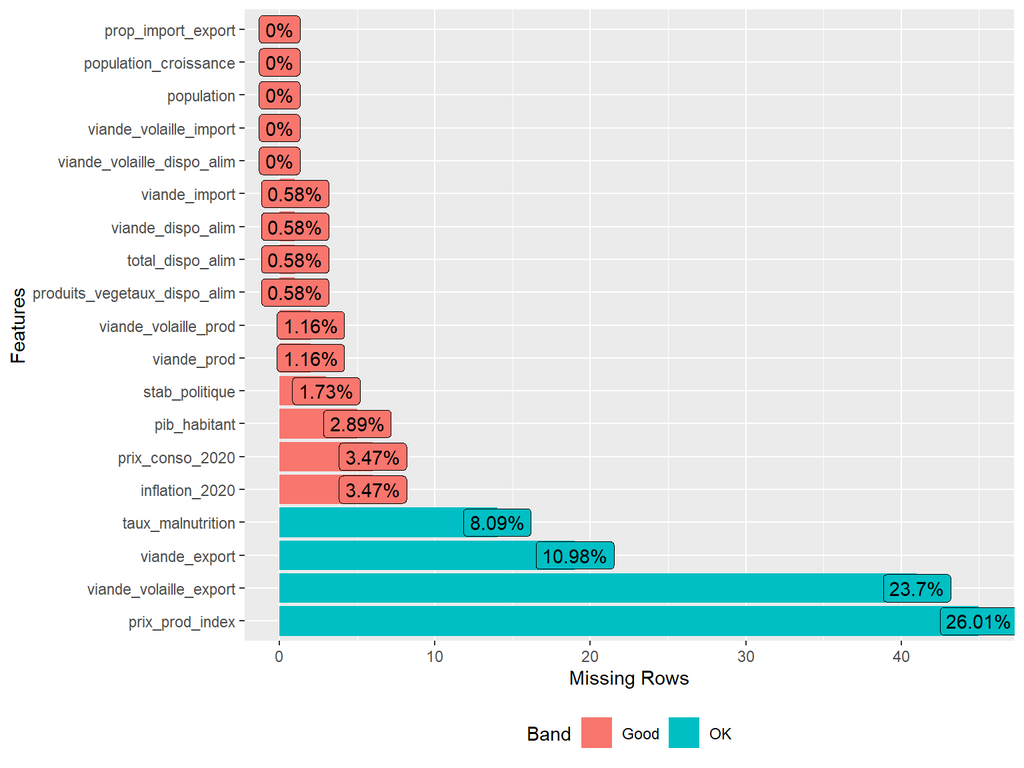

# Methode d’imputation utilisé

Avant d’effectuer notre analyse on a imputé les données manquantes avec une méthode basé sur l’analyse des composantes principales:

```r
library(missMDA)

#imputation des valeurs manquantes
#estimation du nombre de composantes nécessaires à l'imputation
estim_ncpPCA(countries.data,scale = FALSE)
#on retient 5 composantes et on ne réduit pas les variables
res.comp <- imputePCA(countries.data, ncp=5, nb.init = 10, scale = FALSE)
data <- as.data.frame(res.comp$completeObs)

#on va attribuer 0 aux valeurs imputées négatives dans des colonnes spécifiques
data<- data %>%
  mutate(across(viande_export:viande_volaille_prod, ~ replace(., .<0, 0))) %>%
  mutate(viande_export = if_else(viande_export > viande_import + viande_prod, 0, viande_export)) %>%
  mutate(viande_volaille_export = if_else(viande_volaille_export > viande_volaille_import + viande_volaille_prod, 0, viande_volaille_export))

#quick check
which(data<0, arr.ind = TRUE)
```

# Premiere analyse des variables

# Distributions univariées

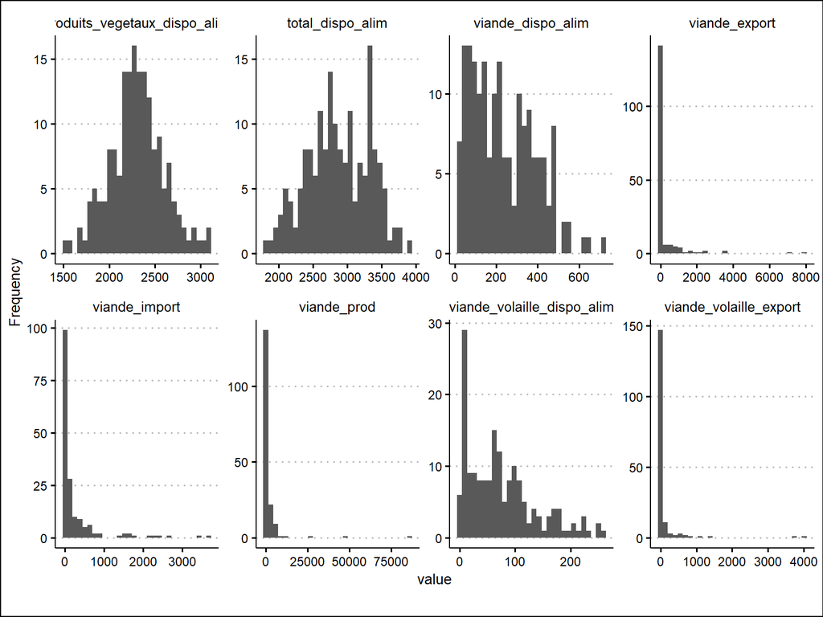

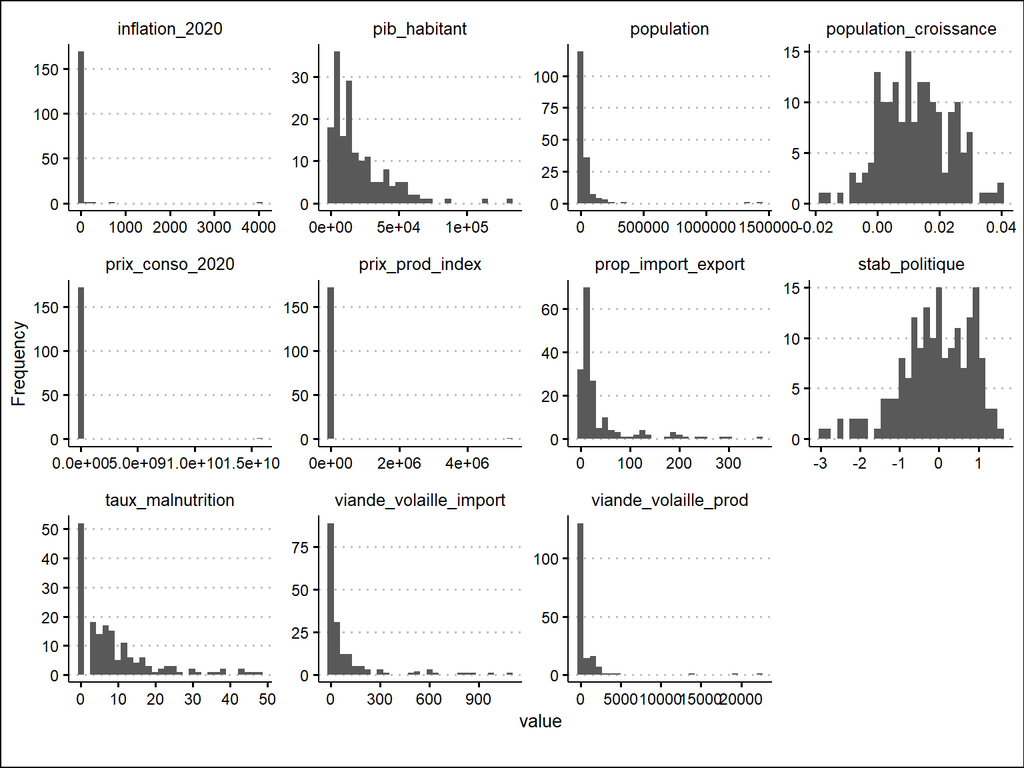

# Matrice des correlations

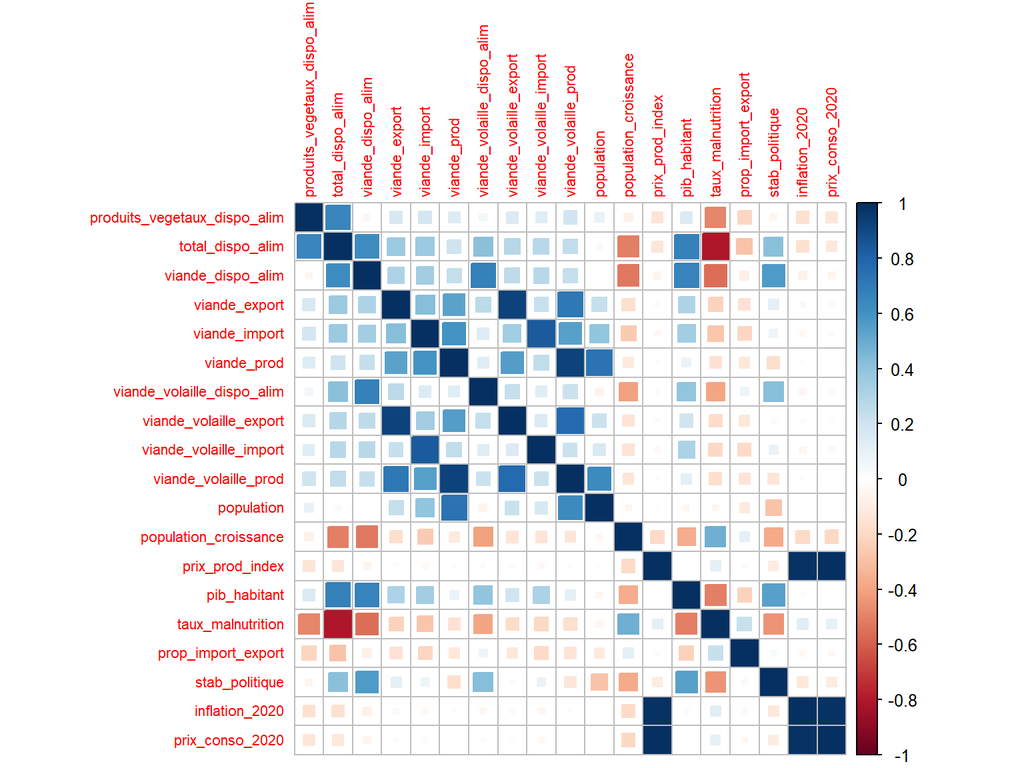

On retiendra les corrélations le plus intéressantes:

- entre taux de malnutrition et le total de disponibilité alimentaire par jour (-0.81)
- entre population et production de viande (0.73)
- entre pib habitant et la disponibilité alimentaire de viande (0.67)

# Clustering

# CAH

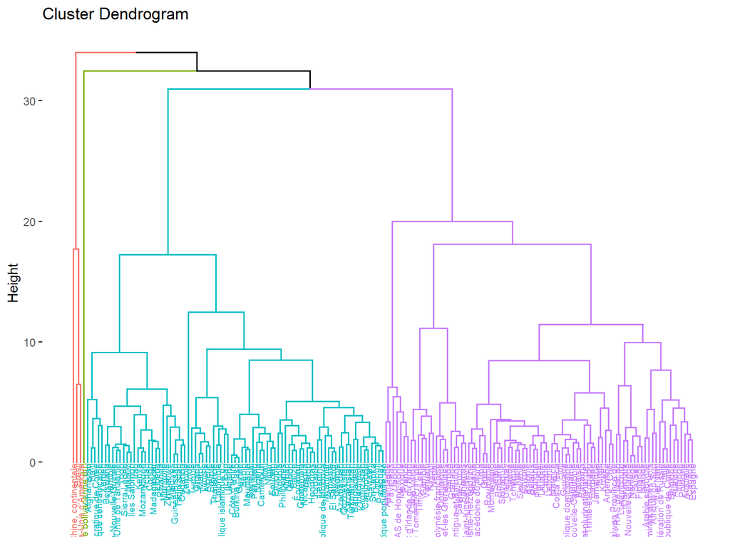

```r
#on choisit 4 groupes
data.hclust <- hcut(data.matrix, 4, method = "ward.D")

fviz_dend(data.hclust, cex = 0.5)
```

# CAH et Kmeans sur le 1er plan factoriel

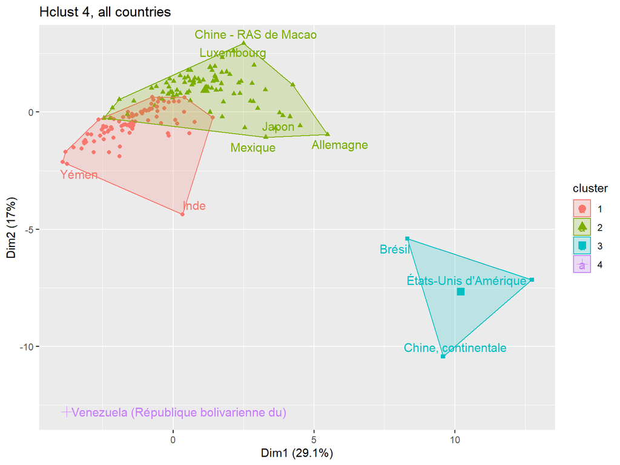

```r
#on visualise les clusters ainsi obtenus (projetés sur le 1er plan factoriel)

fviz_cluster(data.hclust, main = 'Hclust 4, all countries', repel = TRUE)
```

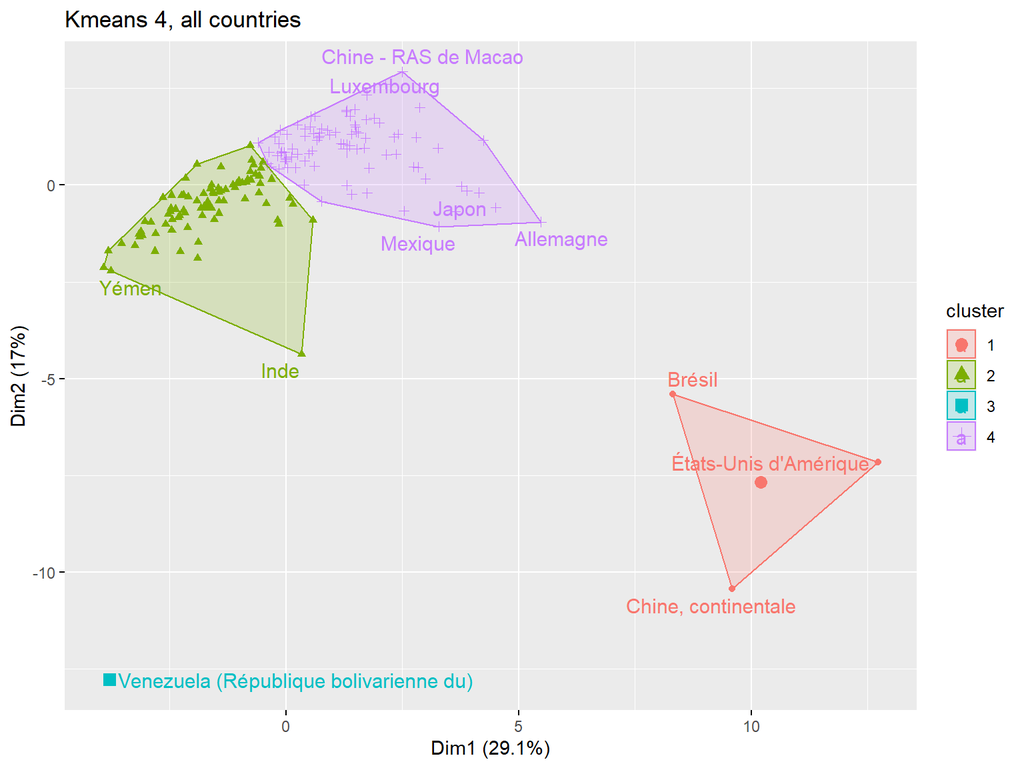

```r
fviz_cluster(data.km, data = data, main = "Kmeans 4, all countries", repel = TRUE)
```

# Centroids et parangons

| cluster | produits_vegetaux_dispo_alim | total_dispo_alim | viande_dispo_alim | viande_export | viande_import | viande_prod | viande_volaille_dispo_alim | viande_volaille_export | viande_volaille_import | viande_volaille_prod | population | population_croissance | prix_prod_index | pib_habitant | taux_malnutrition | prop_import_export | stab_politique | inflation_2020 | prix_conso_2020 |
| --- | --- | --- | --- | --- | --- | --- | --- | --- | --- | --- | --- | --- | --- | --- | --- | --- | --- | --- | --- |
| 1 | 2279.628 | 2598.766 | 123.9066 | 50.3426 | 64.91998 | 778.2613 | 34.98795 | 26.43460 | 37.26506 | 345.8433 | 47757.28 | 0.019262807 | 8.007370e+03 | 7622.108 | 14.743166 | 31.457831 | -0.6778313 | 21.290878 | 3.412774e+06 |
| 2 | 2322.988 | 3122.163 | 337.1860 | 358.8488 | 405.70930 | 1302.9884 | 110.68605 | 92.67879 | 140.22093 | 477.5698 | 17397.43 | 0.006353217 | 6.071088e+03 | 32262.340 | 3.344876 | 47.744186 | 0.5340008 | 5.100071 | 3.293657e+06 |
| 3 | 2554.333 | 3429.667 | 469.6667 | 5323.6667 | 2016.00000 | 53586.3333 | 162.66667 | 2794.00000 | 211.66667 | 18543.6667 | 654737.67 | 0.006238590 | 8.928333e+01 | 30593.067 | 0.000000 | 5.333333 | -0.8236079 | 6.990000 | 1.188567e+02 |
| 4 | 1773.000 | 2120.000 | 123.0000 | 0.0000 | 59.00000 | 1020.0000 | 54.00000 | 0.00000 | 3.00000 | 448.0000 | 28887.00 | -0.017515815 | 5.227973e+06 | 20356.608 | 23.400000 | 11.000000 | -1.3200000 | 4026.670000 | 1.576726e+10 |

| cluster | produits_vegetaux_dispo_alim | total_dispo_alim | viande_dispo_alim | viande_export | viande_import | viande_prod | viande_volaille_dispo_alim | viande_volaille_export | viande_volaille_import | viande_volaille_prod | population | population_croissance | prix_prod_index | pib_habitant | taux_malnutrition | prop_import_export | stab_politique | inflation_2020 | prix_conso_2020 |
| --- | --- | --- | --- | --- | --- | --- | --- | --- | --- | --- | --- | --- | --- | --- | --- | --- | --- | --- | --- |
| 1 | 2554.333 | 3429.667 | 469.6667 | 5323.66667 | 2016.00000 | 53586.3333 | 162.66667 | 2794.00000 | 211.66667 | 18543.6667 | 654737.67 | 0.006238590 | 8.928333e+01 | 30593.067 | 0.000000 | 5.333333 | -0.8236079 | 6.990000 | 1.188567e+02 |
| 2 | 2241.158 | 2534.562 | 119.8464 | 38.92091 | 55.38986 | 649.3094 | 33.10843 | 16.72683 | 31.89157 | 274.9276 | 45216.29 | 0.020225382 | 9.149837e+03 | 6516.071 | 15.635937 | 48.939759 | -0.5710843 | 21.271480 | 3.412772e+06 |
| 3 | 1773.000 | 2120.000 | 123.0000 | 0.00000 | 59.00000 | 1020.0000 | 54.00000 | 0.00000 | 3.00000 | 448.0000 | 28887.00 | -0.017515815 | 5.227973e+06 | 20356.608 | 23.400000 | 11.000000 | -1.3200000 | 4026.670000 | 1.576726e+10 |
| 4 | 2360.116 | 3184.128 | 341.1047 | 369.87209 | 414.90698 | 1427.4419 | 112.50000 | 102.04792 | 145.40698 | 546.0116 | 19849.78 | 0.005424221 | 4.968474e+03 | 33329.795 | 2.483248 | 30.872093 | 0.4309775 | 5.118792 | 3.293658e+06 |

# Comparaison

```r
table(data.hclust$cluster, data.km$cluster)
```

```
##
##      1  2  3  4
##   1  0 75  0  8
##   2  0  8  0 78
##   3  3  0  0  0
##   4  0  0  1  0
```

# Resultats

4 groupes ont été identifiés :

1. Groupe de plus **forts producteurs** mondiaux, populations massives.
2. **Pays “pauvres”** (`pib_habitant` moyen le plus bas), prix à la conso le plus élevé.
3. Cluster constitué uniquement du **Venezuela**. En effet en 2020 ce pays a été confronté à une forte crise inflationnaire, ce qui le place “très loin” des autre pays.
4. **Pays riches**, producteur et importateur de viande.

Les groupes de pays Brésil,USA & Chine a été isolé de façon identique par les deux algorithmes. Les deux autres groupes sont très similaires, le Kmeans faisant une distinction plus nette entre le deux.

# Analyse des composantes principales

# ACP sur le dataset complet

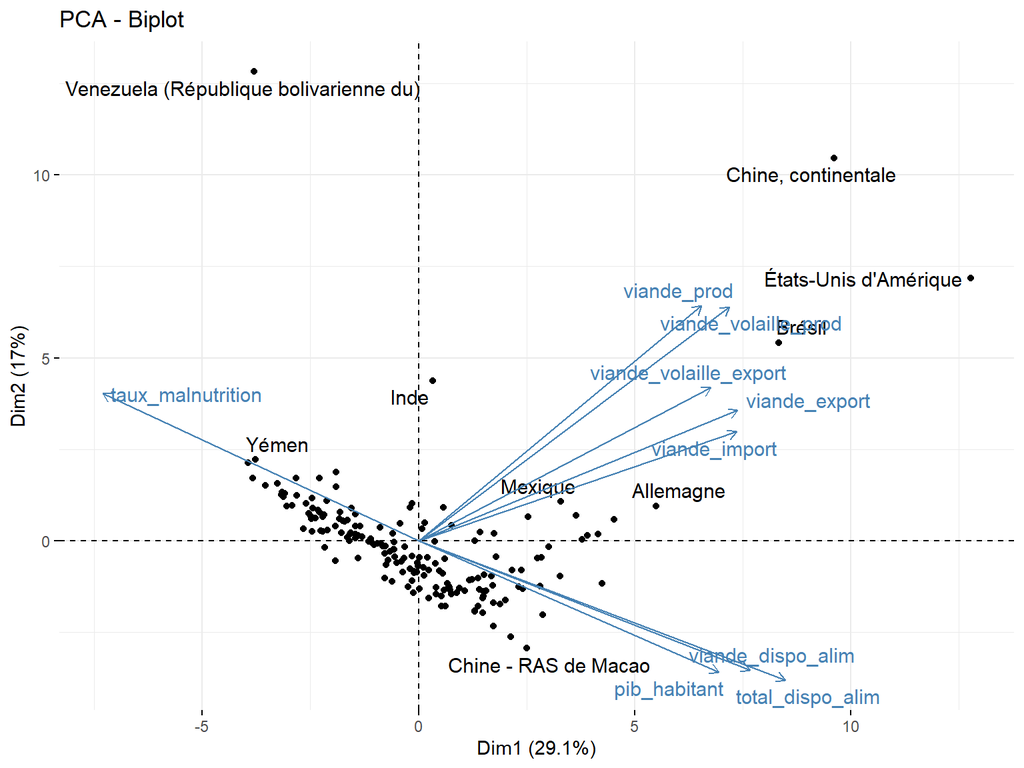

Les variables qui mieux nous permettent de mieux interpréter les axes sont `total_dispo_alim` pour la première dimension et `viande_prod` pour la deuxième. Le deuxième plan est caractérise principalement par `prix_prod` et `produits_vegetaux_dispo_alim`.

On peut maintenant appliquer un CAH sur les composantes principales.

# Clustering sur ACP

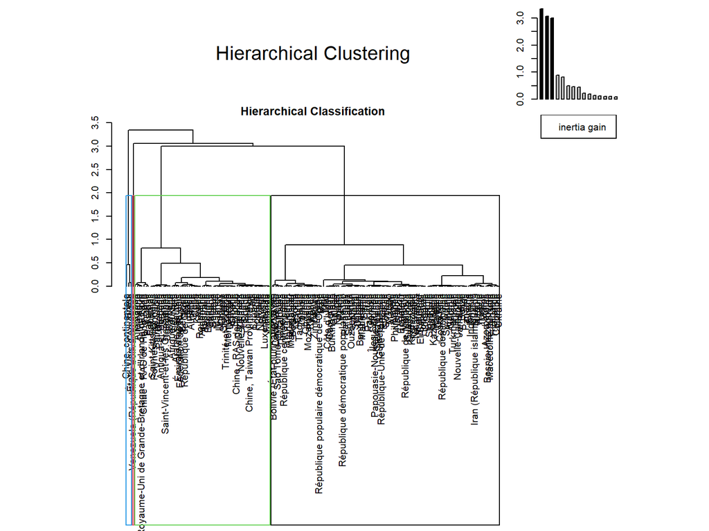

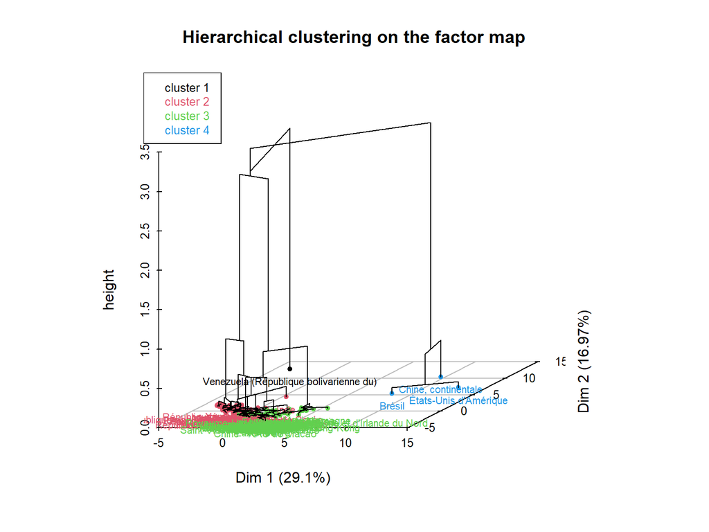

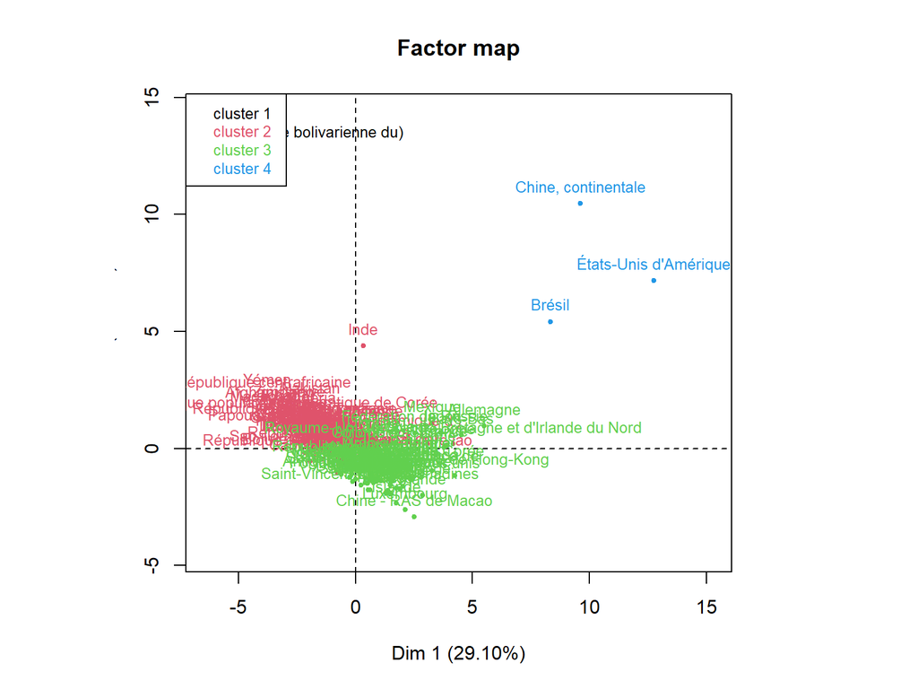

```r
#clustering de l'acp
res.clust <- HCPC(res.pca, 4)
```

## Comparaison des deux methodes

```r
table(res.clust$data.clust$clust, data.hclust$cluster)
```

```
##
##      1  2  3  4
##   1  0  0  0  1
##   2 79  9  0  0
##   3  4 77  0  0
##   4  0  0  3  0
```

Les résultats sont très similaires au CAH appliqué précédemment:

1. Venezuela(crise inflationnaire), (forts valeurs pour les variables `prix_conso_2020`, `prix_prod_index` et `inflation_2020`)
2. Pays pauvres ou avec un fort taux de malnutrition (forts valeurs pour les variables `population_croissance` and `taux_malnutrition`)
3. Pays riches
4. Forts Producteurs

Le groupe 3 c’est ce qu’il nous intéresse car il contient des pays de profil similaires à la France, entre lesquels on pourra sélectionner des candidats potentiels.

# Carte des clusters

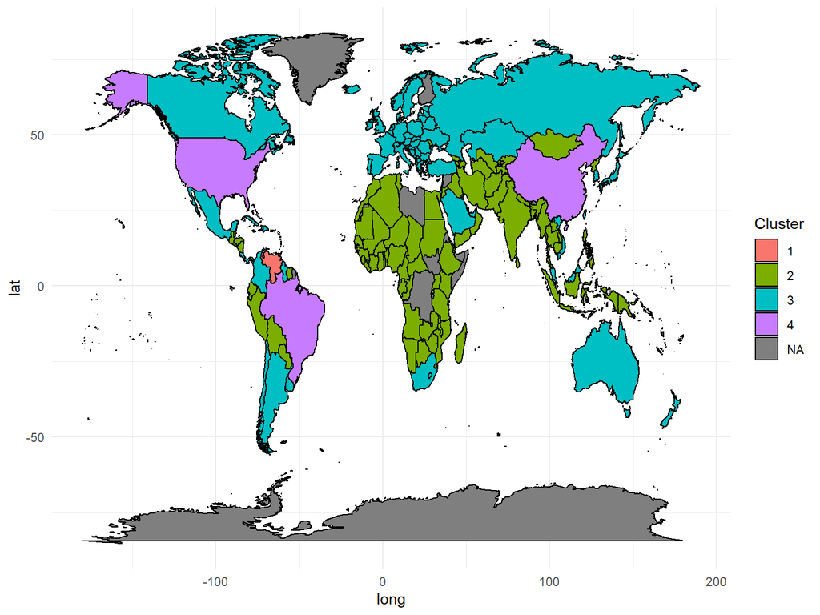

# ACP sur le groupe 3

On va maintenant se concentrer sur le cluster 3, qui contient les pays plus intéressants sous un profil économique.

# Biplot

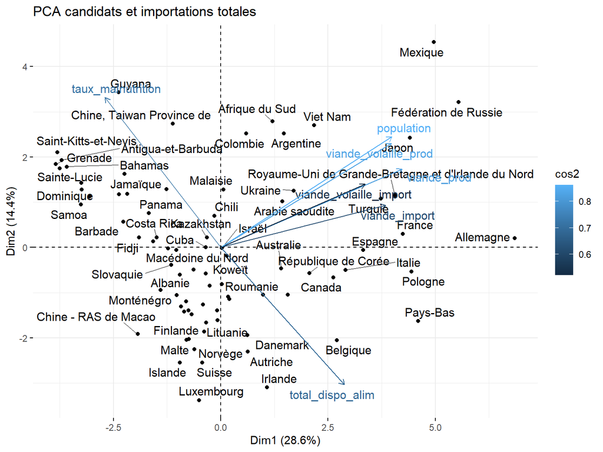

# Clustering du groupe 3

# 3D Dendrogram

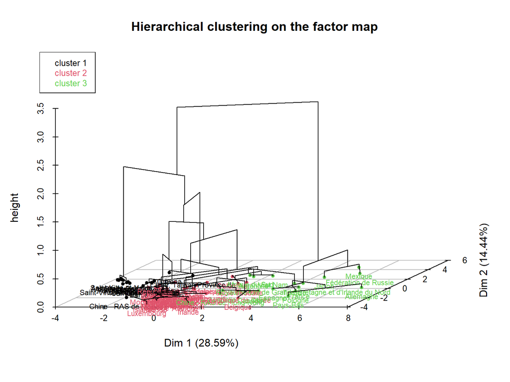

# Projection sur le 1er plan factoriel

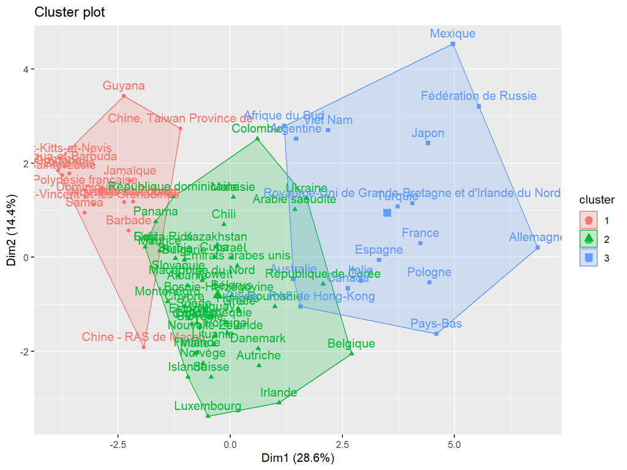

On obtient ainsi 3 clusters:

# Cluster 1

Pays de petit taille, isles, pas très riches mais avec un bon niveau de vie, qui ont déjà une très bonne disponibilité alimentaire de viande de volaille (**Trinité-et-Tobago**, **Barbade**, **Dominique**, **Jamaïque** **Saint-Kitts-et-Nevis**, etc. )

- forts valeurs pour les variables *viande_volaille_dispo_alim*, *prop_import_export*, *taux_malnutrition*, *prix_prod_index* et *prix_conso_2020* (en ordre décroissant).
- faibles valeurs pour les variables *total_dispo_alim*, *produits_vegetaux_dispo_alim*, *pib_habitant*, *viande_prod*, *viande_import*, *population*, *viande_volaille_prod*, *viande_volaille_import* and *viande_export* (en ordre croissant).

# Cluster 2

- forts valeurs pour les variables *stab_politique*, *pib_habitant* and *total_dispo_alim* (ordre décroissant).
- faible valeurs pour *viande_prod*, *viande_volaille_prod*, *population*, *viande_volaille_dispo_alim*, *viande_import*, *taux_malnutrition*, *viande_volaille_import*, *viande_volaille_export*, *viande_export* et *prop_import_export* (ordre croissant).

# Cluster 3

- forts valeurs pour les variables *viande_prod*, *population*, *viande_volaille_prod*, *viande_import*, *viande_volaille_import*, *viande_export*, *viande_volaille_export*, *produits_vegetaux_dispo_alim* et *total_dispo_alim* (ordre décroissant).
- faible valeurs pour *stab_politique*, *prop_import_export* and *prix_prod_index* (ordre croissant).

# Visualisation des variables et des individus des trois groupes

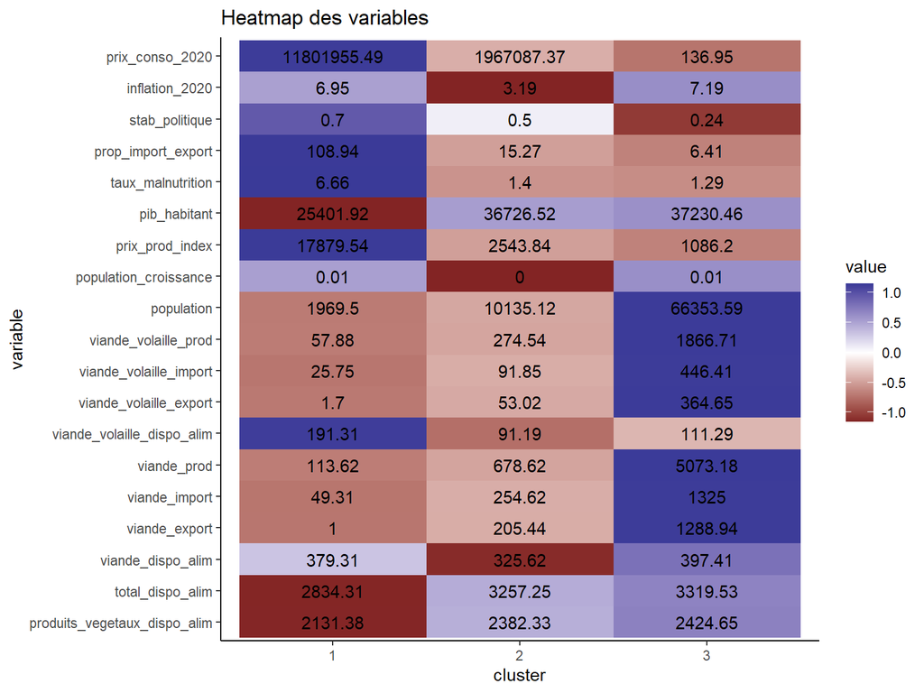

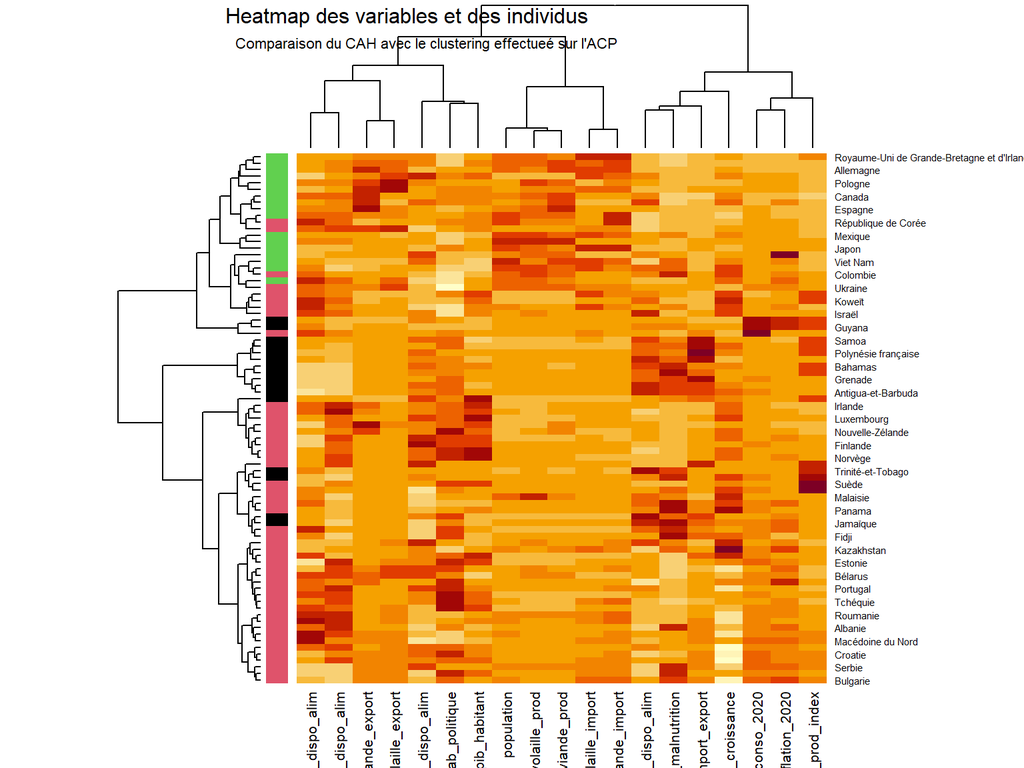

# Carte clusters candidats

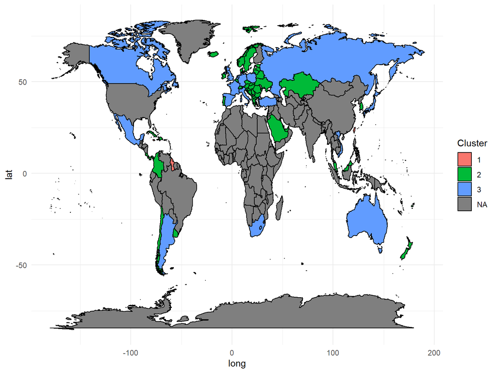

# DBSCAN

# DBSCAN sur le groupe “candidats”

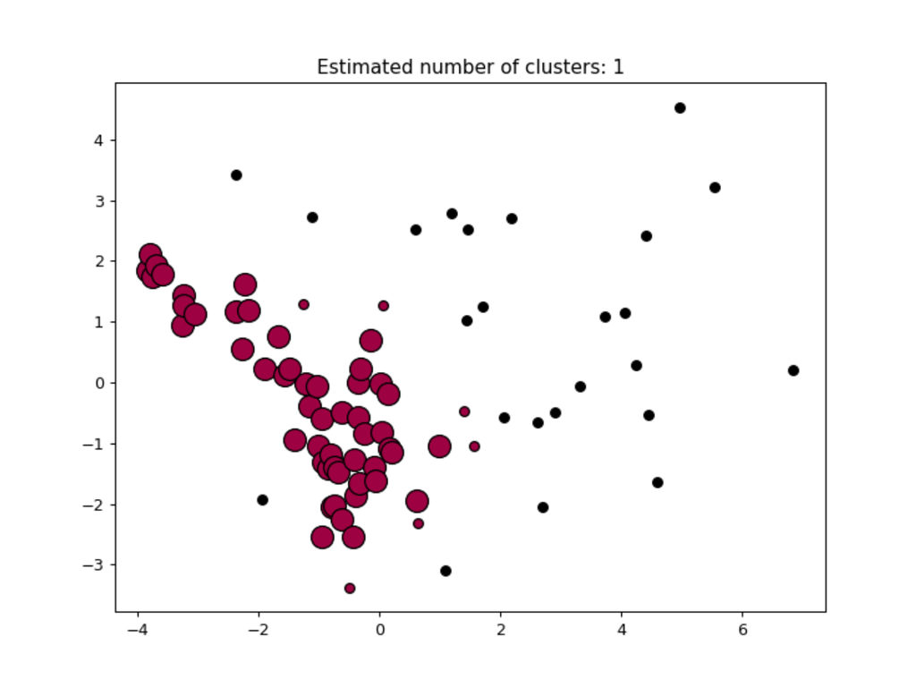

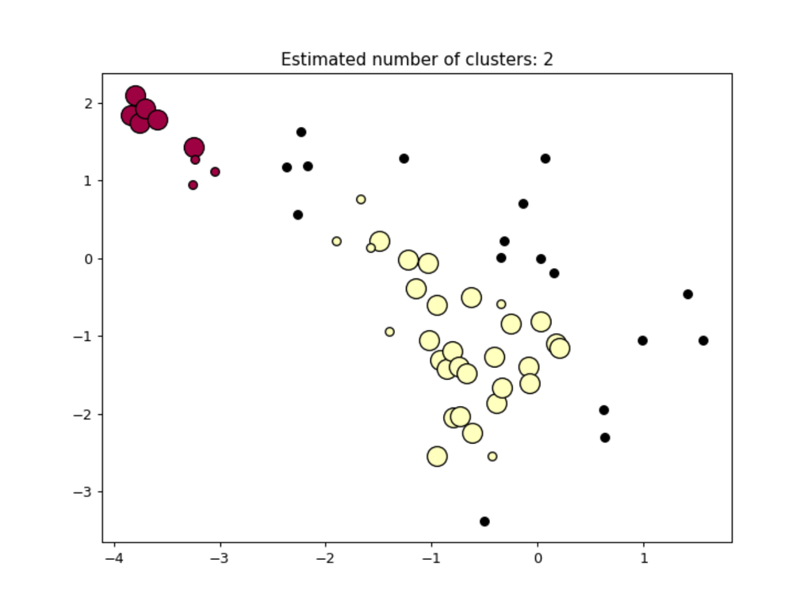

# Resultats du DBSCAN sur le groupe candidats

|  | pays | viande_volaille_import | viande_volaille_prod | population | prix_prod_index | pib_habitant | prix_conso_2020 | indicateur |
| --- | --- | --- | --- | --- | --- | --- | --- | --- |
| 1 | Macédoine du Nord | 40 | 1 | 2083 | 128.84 | 16093.3 | 103.82 | 100244.979 |
| 2 | Tchéquie | 121 | 169 | 10666 | 86.48 | 39933.0 | 113.45 | 31082.218 |
| 3 | Suisse | 45 | 97 | 8526 | 98.22 | 70663.5 | 102.29 | 27819.425 |
| 4 | Slovaquie | 87 | 77 | 5453 | 95.99 | 31132.6 | 111.97 | 17846.446 |
| 5 | Bulgarie | 108 | 118 | 7052 | 91.45 | 22208.5 | 117.52 | 13337.603 |
| 6 | Grèce | 82 | 246 | 10522 | 86.69 | 29150.7 | 101.74 | 11592.185 |
| 7 | Portugal | 85 | 353 | 10256 | 82.29 | 34040.7 | 105.26 | 9705.330 |
| 8 | Estonie | 30 | 19 | 1323 | 84.31 | 35208.0 | 114.65 | 7608.792 |
| 9 | Lettonie | 47 | 34 | 1928 | 100.04 | 30036.1 | 113.11 | 7074.485 |
| 10 | Croatie | 26 | 64 | 4156 | 96.46 | 27799.8 | 105.30 | 4620.989 |

# DBSCAN sur le dataset entier

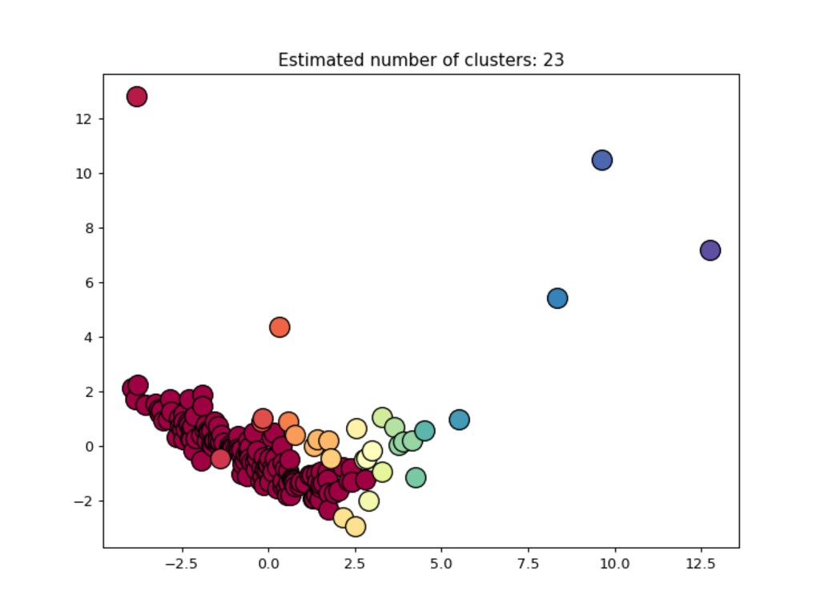

```r
#On peut aussi essayer sur le dataframe complet
full <- res.clust$call$X

py_run_file("dbscan_fulldf.py")
```

|  | pays | label |
| --- | --- | --- |
| 1 | États-Unis d'Amérique | 22 |
| 2 | Chine, continentale | 21 |
| 3 | Brésil | 20 |
| 4 | Allemagne | 19 |
| 5 | Pays-Bas | 18 |
| 6 | Chine - RAS de Hong-Kong | 17 |
| 7 | France | 16 |
| 8 | Pologne | 16 |
| 9 | Royaume-Uni de Grande-Bretagne et d'Irlande du Nord | 16 |
| 10 | Japon | 15 |

# Recommendations

Sur la base des méthodes de clustering utilisées, on peut identfier deux groupes finales de clients :

# Pays à cibler en premier lieu pour l’exportation:

| Pays | viande_volaille_import | viande_volaille_prod | population | pib_habitant | indicateur |
| --- | --- | --- | --- | --- | --- |
| Chine - RAS de Hong-Kong | 821 | 25 | 7372 | 61062.9 | 14783113149 |
| Japon | 1089 | 2250 | 127202 | 41182.4 | 2535426084 |
| Allemagne | 871 | 1571 | 83124 | 53463.4 | 2463910781 |
| Royaume-Uni de Grande-Bretagne et d'Irlande du Nord | 802 | 1939 | 67142 | 46037.9 | 1278516503 |
| Mexique | 983 | 3377 | 126191 | 19928.4 | 732020546 |
| Pays-Bas | 585 | 1074 | 17060 | 56060.9 | 520943564 |
| Viet Nam | 593 | 947 | 95546 | 7585.9 | 453862539 |
| Espagne | 189 | 1622 | 46693 | 40312.5 | 219332235 |
| Canada | 177 | 1474 | 37075 | 48796.8 | 217244247 |
| Afrique du Sud | 515 | 1762 | 57793 | 12627.9 | 213308272 |

[output cut: 6 more lines]

# Marchés potentiellement intéressants:

| Pays | viande_volaille_import | viande_volaille_prod | population | pib_habitant | prix_conso_2020 | indicateur |
| --- | --- | --- | --- | --- | --- | --- |
| Luxembourg | 12 | 0 | 604 | 113590.00 | 111.14 | Inf |
| Émirats arabes unis | 609 | 48 | 9631 | 66968.20 | 108.24 | 7.560113e+07 |
| Arabie saoudite | 640 | 554 | 33703 | 47592.80 | 115.96 | 1.597982e+07 |
| Macédoine du Nord | 40 | 1 | 2083 | 16093.30 | 103.82 | 1.291556e+07 |
| Koweït | 147 | 61 | 4137 | 50478.60 | 107.09 | 4.699281e+06 |
| République de Corée | 170 | 885 | 51172 | 41948.30 | 113.58 | 3.630367e+06 |
| Belgique | 303 | 470 | 11482 | 51111.00 | 109.65 | 3.450389e+06 |
| Kazakhstan | 195 | 183 | 18320 | 25544.30 | 150.98 | 3.302810e+06 |
| Irlande | 105 | 150 | 4819 | 84303.30 | 92.70 | 3.067749e+06 |
| Autriche | 114 | 152 | 8891 | 55297.60 | 123.88 | 2.976576e+06 |

[output cut: 38 more lines]

Pour une première choix on peut aussi considérer le résultats du DBSCAN, qui met en évidence les pays le plus proches à la France en terme de profil général et qui sont déjà présents dans la première liste : Pologne et Royaume. Uni.